# Importing Libraries

#### It's difficult to say much about the class by just observing the scatter plots of P_radius with the other variables and the class

##### S_degree

```python
## Checking the summary of S_Degree

df.S_Degree.describe()
```

```
count    310.000000
mean      26.296694
std       37.559027
min      -11.058179
25%        1.603727
50%       11.767934
75%       41.287352
max      418.543082
Name: S_Degree, dtype: float64
```

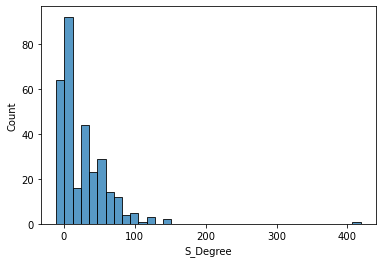

```python
## Checking the distribution of S_degree in a histogram

sns.histplot(df.S_Degree);
```

Since there is an extreme outlier it would be difficult to analyze data through plots as they will always be concentrated to one side to accomodate that single outlier on one end.

Therefore we should remove that outlier from the data just for the sake of analyzing the S_Degree variable through plots

```python
## Removing the outlier on the higher side

df1=df[df.S_Degree<400]
```

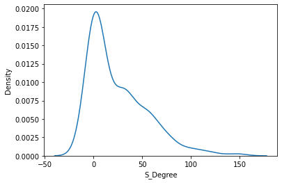

```python
## Checking the distribution of S_Degree in a kdeplot

sns.kdeplot(df1.S_Degree);
```

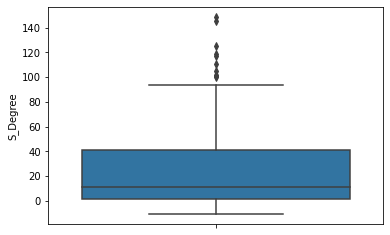

```python
## Checking the distribution of S_Degree through a boxplot

sns.boxplot(y=df1.S_Degree);
```

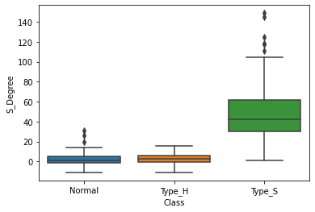

```python
## Checking the distribution of S_degree by Class through a boxplot

sns.boxplot(x=df1.Class, y=df1.S_Degree);
```

```python
## ANOVA to check if Class is dependent on S_Degree

import statsmodels.api as sm
from statsmodels.formula.api import ols

mod = ols('S_Degree ~ Class', data = df).fit()
aov_table = sm.stats.anova_lm(mod, typ = 2)
print(aov_table)
```

```
                 sum_sq     df           F        PR(>F)
Class     190467.122010    2.0  119.122881  5.114732e-39
Residual  245433.144996  307.0         NaN           NaN
```

since p value <0.05 we reject the Null Hypothesis that the average S_degree for all classes is same. Therefore Class is dependent on S_degree

```python
## Checking the summary of S_Degree for class Normal

df1[df1.Class=='Normal'].S_Degree.describe()
```

```
count    100.000000
mean       2.186572
std        6.307483
min      -11.058179
25%       -1.511360
50%        1.152710
75%        4.968807
max       31.172767
Name: S_Degree, dtype: float64
```

```python
## Checking the summary of S_Degree for class Type_H

df1[df1.Class=='Type_H'].S_Degree.describe()
```

```
count    60.000000
mean      2.480251
std       5.531177
min     -10.675871
25%      -0.910819
50%       2.542441
75%       6.059666
max      15.779697
Name: S_Degree, dtype: float64
```

```python
## Checking the summary of S_Degree for class Type_S

df1[df1.Class=='Type_S'].S_Degree.describe()
```

```
count    149.000000
mean      49.435973
std       26.554083
min        1.010041
25%       30.387984
50%       42.136943
75%       61.700598
max      148.753711
Name: S_Degree, dtype: float64
```

#### The distribution of the attribute S_degree for the three classes makes is apparent that the value of S_degree for the classes Normal and Type_H are quite small with that for Type_S is quite large

```python
print("Correlation between S_Degree and P_incidence is",df1.S_Degree.corr(df1.P_incidence).round(2))
print("Correlation between S_Degree and P_tilt is",df1.S_Degree.corr(df1.P_tilt).round(2))
print("Correlation between S_Degree and L_angle is",df1.S_Degree.corr(df1.L_angle).round(2))
print("Correlation between S_Degree and S_slope is",df1.S_Degree.corr(df1.S_slope).round(2))
print("Correlation between S_Degree and P_radius is",df1.S_Degree.corr(df1.P_radius).round(2))
```

```
Correlation between S_Degree and P_incidence is 0.64
Correlation between S_Degree and P_tilt is 0.53
Correlation between S_Degree and L_angle is 0.67
Correlation between S_Degree and S_slope is 0.43
Correlation between S_Degree and P_radius is -0.0
```

#### Making scatterplots with other variables and class variable to check the relationships with S_Degree

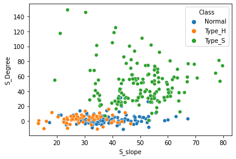

```python
sns.scatterplot(x=df1.S_slope,y=df1.S_Degree,hue=df1.Class);
```

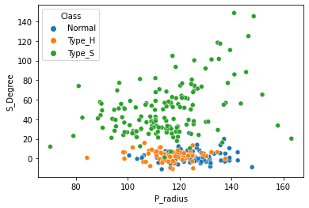

```python
sns.scatterplot(x=df1.P_radius,y=df1.S_Degree,hue=df1.Class);
```

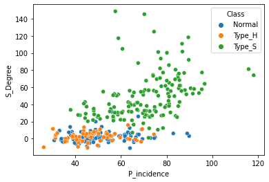

```python
sns.scatterplot(x=df1.P_incidence,y=df1.S_Degree,hue=df1.Class);
```

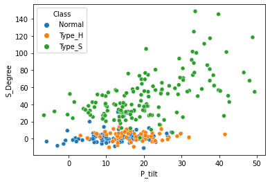

```python
sns.scatterplot(x=df1.P_tilt,y=df1.S_Degree,hue=df1.Class);
```

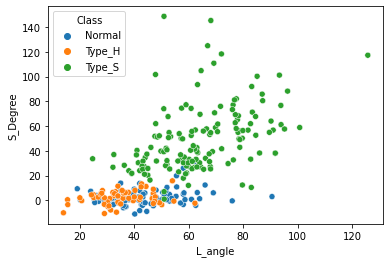

```python
sns.scatterplot(x=df1.L_angle,y=df1.S_Degree,hue=df1.Class);
```

#### Through observing the distribution of S_Degree and the scatterplots with other variables and the classes it seems that the predictibility of the class due to the S_degree variable is significantly higher than the other variables.

#### If the S_degree is high it is more likely to be of the class Type_S. While it is still difficult to predict for other classes with S_degree alone

### Multivariate - Pairplot and Correlation matrix

```python
## Correlation Matrix

df.corr()
```

|  | P_incidence | P_tilt | L_angle | S_slope | P_radius | S_Degree |
| --- | --- | --- | --- | --- | --- | --- |
| P_incidence | 1.000000 | 0.629199 | 0.717282 | 0.814960 | -0.247467 | 0.638743 |
| P_tilt | 0.629199 | 1.000000 | 0.432764 | 0.062345 | 0.032668 | 0.397862 |
| L_angle | 0.717282 | 0.432764 | 1.000000 | 0.598387 | -0.080344 | 0.533667 |
| S_slope | 0.814960 | 0.062345 | 0.598387 | 1.000000 | -0.342128 | 0.523557 |
| P_radius | -0.247467 | 0.032668 | -0.080344 | -0.342128 | 1.000000 | -0.026065 |
| S_Degree | 0.638743 | 0.397862 | 0.533667 | 0.523557 | -0.026065 | 1.000000 |

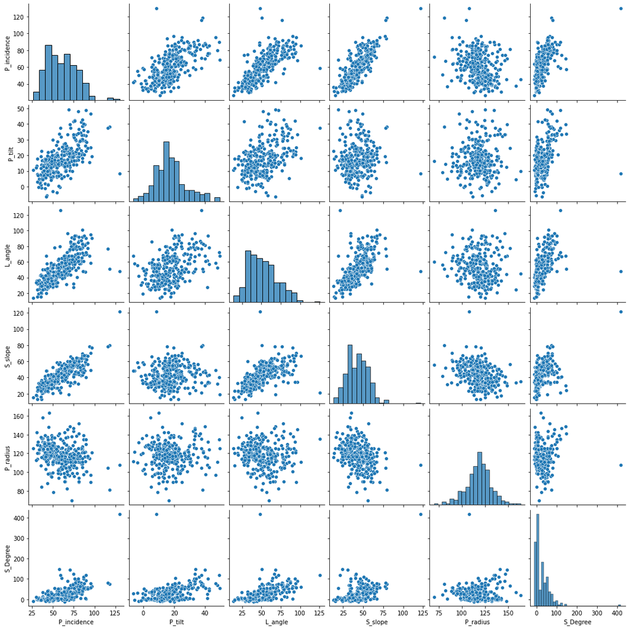

```python
## Pairplot

sns.pairplot(df);
```

#### Although the Correlation matrix and pairplot help us see the relationships between variables and the distributions at one go. They are generally difficult to read. Moreover, in this case they do not give us anything more than what we have already observed through the various distribution plots and scatter plots

# Data Preprocessing

```python
## Separating the X variables from the target variable

df.reset_index(inplace=True)
df.drop('index', axis = 1, inplace=True)
X = df.iloc[:,:-1]
y = df.iloc[:,-1]
```

```python
X
```

|  | P_incidence | P_tilt | L_angle | S_slope | P_radius | S_Degree |
| --- | --- | --- | --- | --- | --- | --- |
| 0 | 38.505273 | 16.964297 | 35.112814 | 21.540976 | 127.632875 | 7.986683 |
| 1 | 54.920858 | 18.968430 | 51.601455 | 35.952428 | 125.846646 | 2.001642 |
| 2 | 44.362490 | 8.945435 | 46.902096 | 35.417055 | 129.220682 | 4.994195 |
| 3 | 48.318931 | 17.452121 | 48.000000 | 30.866809 | 128.980308 | -0.910941 |
| 4 | 45.701789 | 10.659859 | 42.577846 | 35.041929 | 130.178314 | -3.388910 |
| ... | ... | ... | ... | ... | ... | ... |
| 305 | 80.111572 | 33.942432 | 85.101608 | 46.169139 | 125.593624 | 100.292107 |
| 306 | 95.480229 | 46.550053 | 59.000000 | 48.930176 | 96.683903 | 77.283072 |
| 307 | 74.094731 | 18.823727 | 76.032156 | 55.271004 | 128.405731 | 73.388216 |
| 308 | 87.679087 | 20.365613 | 93.822416 | 67.313473 | 120.944829 | 76.730629 |
| 309 | 48.259920 | 16.417462 | 36.329137 | 31.842457 | 94.882336 | 28.343799 |

310 rows × 6 columns

##### Scaling has to be done after segregating the data into train and test not before it because otherwise we would have a case of information leakage.

```python
## Segregating the data into train and test sets

X_train, X_test, y_train, y_test = train_test_split(X,y, test_size = 0.3, random_state = 42)
```

```python
## Checking the shape of the train and test sets

X_train.shape, X_test.shape, y_train.shape, y_test.shape
```

```
((217, 6), (93, 6), (217,), (93,))
```

##### Checking the ratio of the classes in the train vs the test set

```python
## Ratio of Normal class in train vs test sets

round(y_train.value_counts().Normal/len(y_train),2),round(y_test.value_counts().Normal/len(y_test),2)
```

```
(0.31, 0.34)
```

```python
## Ratio of Type_H class in train vs test sets

round(y_train.value_counts().Type_H/len(y_train),2),round(y_test.value_counts().Type_H/len(y_test),2)
```

```
(0.19, 0.2)
```

```python
## Ratio of Type_S class in train vs test sets

round(y_train.value_counts().Type_S/len(y_train),2),round(y_test.value_counts().Type_S/len(y_test),2)
```

```
(0.5, 0.45)
```

#### The Ratio of the classes in the train set vs the test is more or less similar

We see that in the train set class Normal has 31% of the data points, class Type_H has 19% of the data points, class Type_S has 50% of the data points

Although the classes are slightly imbalanced if we try to undersample to achieve target balancing we will lose out data.

If we try to copy and add more data for the 'Normal' and 'Type_H' classes we will not really be adding any data.

Thirdly, we can use techniques like SMOTE to get synthetic data for the two classes (Normal and Type_H), but we would be adding bias.

#### Since the classes are only slightly imbalanced. In my opinion we do not need to perform any undersampling or oversampling.

##### Standardizing the data

```python
sc = StandardScaler()
```

```python
sc.fit(X_train)
X_train = sc.transform(X_train)
```

#### Also standardizing X_test beforehand

```python
X_test = sc.transform(X_test)
```

# Model Training, Testing and Tuning

```python
k = round(np.sqrt(217))
k
```

```
15
```

```python
model_KNN_1 = KNeighborsClassifier(n_neighbors=k)
```

```python
model_KNN_1.fit(X_train,y_train)
```

```
KNeighborsClassifier(n_neighbors=15)
```

```python
print(f'Model Accuracy for KNN model with K = 15 on train set is {100*(round(model_KNN_1.score(X_train,y_train),3))}%')
```

```
Model Accuracy for KNN model with K = 15 on train set is 78.3%
```

```python
y_pred = model_KNN_1.predict(X_test)
print(f'Model Accuracy for KNN model with K = 15 on test set is {round(accuracy_score(y_test,y_pred),4)*100}%')
```

```
Model Accuracy for KNN model with K = 15 on test set is 82.8%
```

```python
## Stacking up the predictions against the actuals

y_grid = np.column_stack([y_test.values,y_pred])
print(y_grid)
```

```
[['Type_S' 'Type_S']
 ['Normal' 'Type_H']
 ['Normal' 'Normal']
 ['Normal' 'Normal']
 ['Normal' 'Type_H']
 ['Normal' 'Normal']
 ['Normal' 'Type_H']
 ['Type_S' 'Type_S']
 ['Type_S' 'Type_S']
 ['Normal' 'Normal']
 ['Normal' 'Normal']
 ['Type_S' 'Type_S']
 ['Type_S' 'Type_S']
 ['Type_S' 'Type_S']
 ['Type_S' 'Type_S']
 ['Type_S' 'Type_S']
 ['Normal' 'Normal']
 ['Type_H' 'Type_H']
 ['Type_S' 'Type_S']
 ['Type_S' 'Type_S']
 ['Normal' 'Normal']
 ['Type_H' 'Type_H']
 ['Type_H' 'Type_H']
 ['Type_S' 'Type_S']
 ['Normal' 'Normal']
 ['Type_S' 'Type_H']
 ['Type_H' 'Type_H']
 ['Normal' 'Normal']
 ['Type_S' 'Type_S']
 ['Type_S' 'Normal']
 ['Type_H' 'Normal']
 ['Normal' 'Normal']
 ['Normal' 'Normal']
 ['Type_S' 'Type_S']
 ['Normal' 'Normal']
 ['Type_H' 'Type_H']
 ['Normal' 'Type_S']
 ['Normal' 'Normal']
 ['Type_S' 'Type_S']
 ['Type_H' 'Normal']
```

[output cut: 38 more lines]

```
 ['Type_H' 'Type_H']
 ['Type_S' 'Type_S']
 ['Type_S' 'Type_S']
 ['Type_S' 'Type_S']
 ['Type_H' 'Normal']
 ['Type_S' 'Type_S']
 ['Normal' 'Normal']
 ['Type_S' 'Type_S']
 ['Normal' 'Normal']
 ['Type_H' 'Normal']
 ['Type_S' 'Type_S']
 ['Type_S' 'Type_S']
 ['Normal' 'Normal']
 ['Type_H' 'Type_H']
 ['Normal' 'Normal']]
```

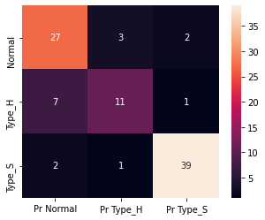

```python
lab = ['Normal', 'Type_H', 'Type_S']
plab = ['Pr Normal', 'Pr Type_H', 'Pr Type_S']
cm = confusion_matrix(y_test,y_pred,labels = lab)

df_cm = pd.DataFrame(cm, index = [i for i in lab], columns = [i for i in plab])
plt.figure(figsize = (5,4))
sns.heatmap(df_cm ,annot=True, fmt = 'g');
```

```python
print(classification_report(y_test.values,y_pred, ))
```

```
              precision    recall  f1-score   support

      Normal       0.75      0.84      0.79        32
      Type_H       0.73      0.58      0.65        19
      Type_S       0.93      0.93      0.93        42

    accuracy                           0.83        93
   macro avg       0.80      0.78      0.79        93
weighted avg       0.83      0.83      0.82        93
```

The Classification report states the Precision, Recall and F1-Score of the three classes and it gives a better measure of model performance than just accuracy

Recall gives us the correct predictions of the given class out of all the times the class occurs in the dataset The recall for Normal is 0.84, Type_H is 0.58 and Type_S is 0.93 Therefore we can say that if the class Normal occurs 100 times in the data we predicted it correctly 84 times

Precision gives us what proportion of positive classification for every class was actually correct The precision for Normal is 0.75, Type_H is 0.73 and Type_S is 0.93 Therefore we can say if we classified a 100 patients in the Normal category we were right 75 times

F1 Score is a combination of both the metrics Precision and Recall. It balances the aspects of both Precision and Recall. It is the harmonic mean of Precision and Recall

The F1 Score for Normal is 0.79, Type_H is 0.65 and Type_S is 0.93

Therefore we see that we are able to predict Type_S well while prediction for Type_H and Normal Categories is rather poor

### Choosing the best values of K

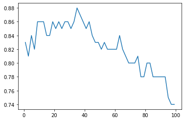

```python
acc_scores = []
best_k_values = []
for k in range(1,101,2):
    model_KNN_2 = KNeighborsClassifier(n_neighbors = k, weights = 'distance' )
    model_KNN_2.fit(X_train, y_train)
    acc_scores.append(round(model_KNN_2.score(X_test, y_test),2))
    if (model_KNN_2.score(X_test, y_test)) >0.86:
        best_k_values.append(k)

sns.lineplot(x= range(1,101,2), y = acc_scores);
```

```python
print("The best Values of K for the current Data are (based on K values that give accuracy scores greater than 86% ):\n\n",best_k_values)
print("\n")
print("Accuracy Scores for different values of K from K = 1 to K = 99 in steps of 2:\n\n",acc_scores)
```

```
The best Values of K for the current Data are (based on K values that give accuracy scores greater than 86% ):

 [9, 11, 13, 19, 23, 27, 29, 33, 35, 37, 39, 43]


Accuracy Scores for different values of K from K = 1 to K = 99 in steps of 2:

 [0.83, 0.81, 0.84, 0.82, 0.86, 0.86, 0.86, 0.84, 0.84, 0.86, 0.85, 0.86, 0.85, 0.86, 0.86, 0.85, 0.86, 0.88, 0.87, 0.86, 0.85, 0.86, 0.84, 0.83, 0.83, 0.82, 0.83, 0.82, 0.82, 0.82, 0.82, 0.84, 0.82, 0.81, 0.8, 0.8, 0.8, 0.81, 0.78, 0.78, 0.8, 0.8, 0.78, 0.78, 0.78, 0.78, 0.78, 0.75, 0.74, 0.74]
```

### Choosing the best tuned model with K, distance_measures, weights and parameter p

```python
## Creating a dataframe with the Hyperparameters and the accuracies achieved with the Hyperparameters

model_df = pd.DataFrame(columns = ['K','p','Weights','Metric','Accuracy'])
iter = 0
for i in range(1,75,2):
    for j in range(1,3):
        for l in ['uniform', 'distance']:
            for m in ['minkowski','chebyshev']:
                model_KNN_3 = KNeighborsClassifier(n_neighbors=i, metric= m, p = j, weights = l)
                model_KNN_3.fit(X_train,y_train)
                score = round(model_KNN_3.score(X_test,y_test),3)
                model_df = model_df.append(pd.DataFrame({'K':i,'p':j,'Weights':l,'Metric':m, 'Accuracy':score}, index = [iter]))
                iter = iter+1
```

```python
## Sorting the values in the dataframe

model_df.sort_values('Accuracy', ascending = False, inplace=True)
```

```python
model_df.head(15)
```

|  | K | p | Weights | Metric | Accuracy |
| --- | --- | --- | --- | --- | --- |
| 142 | 35 | 2 | distance | minkowski | 0.882 |
| 90 | 23 | 1 | distance | minkowski | 0.882 |
| 114 | 29 | 1 | distance | minkowski | 0.871 |
| 80 | 21 | 1 | uniform | minkowski | 0.871 |
| 150 | 37 | 2 | distance | minkowski | 0.871 |
| 82 | 21 | 1 | distance | minkowski | 0.871 |
| 118 | 29 | 2 | distance | minkowski | 0.860 |
| 38 | 9 | 2 | distance | minkowski | 0.860 |
| 46 | 11 | 2 | distance | minkowski | 0.860 |
| 50 | 13 | 1 | distance | minkowski | 0.860 |
| 54 | 13 | 2 | distance | minkowski | 0.860 |
| 58 | 15 | 1 | distance | minkowski | 0.860 |
| 64 | 17 | 1 | uniform | minkowski | 0.860 |
| 78 | 19 | 2 | distance | minkowski | 0.860 |
| 158 | 39 | 2 | distance | minkowski | 0.860 |

#### We can check the classification report for the models to further see the goodness of the model

```python
## Model with Metric = Minkowski, K = 35, weights = distance, p = 2 -----> distance parameter becomes euclidean since for p = 2 minkowski is equal to euclidean

model_KNN_4 = KNeighborsClassifier(n_neighbors=35, metric='minkowski', weights = 'distance', p = 2)
model_KNN_4.fit(X_train,y_train)
print(classification_report(y_test,model_KNN_4.predict(X_test)))
```

```
              precision    recall  f1-score   support

      Normal       0.80      0.88      0.84        32
      Type_H       0.88      0.79      0.83        19
      Type_S       0.95      0.93      0.94        42

    accuracy                           0.88        93
   macro avg       0.88      0.86      0.87        93
weighted avg       0.89      0.88      0.88        93
```

```python
## Model with Metric = Minkowski, K = 23, weights = distance, p = 1 -----> distance parameter becomes manhattan since for p = 1 minkowski is equal to manhattan

model_KNN_5 = KNeighborsClassifier(n_neighbors=23, metric='minkowski', weights = 'distance', p = 1)
model_KNN_5.fit(X_train,y_train)
print(classification_report(y_test,model_KNN_5.predict(X_test)))
```

```
              precision    recall  f1-score   support

      Normal       0.82      0.88      0.85        32
      Type_H       0.82      0.74      0.78        19
      Type_S       0.95      0.95      0.95        42

    accuracy                           0.88        93
   macro avg       0.87      0.85      0.86        93
weighted avg       0.88      0.88      0.88        93
```

##### Other parameters like algorithm selection (auto, kd tree, ball tree, brute etc.) were also tried but did not affect the results

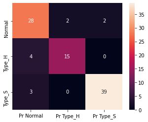

```python
## Confusion Matrix for the best model

lab = ['Normal', 'Type_H', 'Type_S']
plab = ['Pr Normal', 'Pr Type_H', 'Pr Type_S']
cm = confusion_matrix(y_test,model_KNN_4.predict(X_test),labels = lab)

df_cm = pd.DataFrame(cm, index = [i for i in lab], columns = [i for i in plab])
plt.figure(figsize = (5,4))
sns.heatmap(df_cm ,annot=True, fmt = 'g');
```

# Conclusion and Improvisation

### Conclusion on the results

The model prediction results show that it is not very easy to distinguish between the three different classes with the current data set. Although Type_H and Type_S are distinguishable more easily. It is difficult to distinguish the fringe cases of the class Normal from the two classes.

We see that the prediction errors have happened only in trying to distinuguish class Normal from Type_H and Normal from Type_S

We also see that the variable S_degree helps identify Type_S quite well.

Recall gives us the correct predictions of the given class out of all the times the class occurs in the dataset The recall for Normal is 0.88, Type_H is 0.79 and Type_S is 0.93 Therefore we can say that if the class Normal occurs 100 times in the data we predicted it correctly 88 times

Precision gives us what proportion of positive classification for every class was actually correct The precision for Normal is 0.80, Type_H is 0.88 and Type_S is 0.95 Therefore we can say if we classified 100 patients in the Type_H category we were right 88 times

F1 Score is a combination of both the metrics Precision and Recall. It balances the aspects of both Precision and Recall. It is the harmonic mean of Precision and Recall

The F1 Score for Normal is 0.84, Type_H is 0.83 and Type_S is 0.94

This result from the final model is way better than the result on the first model.

### Detailed suggestions or improvements or on quality, quantity, variety, velocity, veracity etc. on the data points collected by the research team to perform a better data analysis in future.

1. While collecting data it would be better if we categorized data well. For example we had categories such as Nrml and tp_s etc also in the data that make data cleansing a necessary step and can also create a situation where the data analyst/scientist can make some wrong analysis
1. While collecting data it would be better if we can collect data equally for all classes otherwise we may have a situation of imbalanced classes
1. If the data is related to medical conditions, we must strive to find variables that better define the conditions. If the predictability of the variables is not very high, we may end up with models with low accuracy and therefore may misclassify conditions
1. There are no questions or suggestions on variety, velocity and veracity as data is tabular, static and seems to have come from a research team